# Cyclistic Bike-Share Analysis

Honey Bear

2024-05-27

# Introduction

This report analyzes the usage patterns of Cyclistic bike-share service by annual members and casual riders. The analysis aims to answer the following questions:

1. How do annual members and casual riders use Cyclistic bikes differently?
2. Why would casual riders buy Cyclistic annual memberships?
3. How can Cyclistic use digital media to influence casual riders to become members?

### Loading Libraries

```r
# Loading Libraries
library(tidyverse)
```

```r
library(ggplot2)
library(knitr)
library(rmarkdown)
library(dplyr)
library(lubridate)
```

### Setting Up Data Frames

```r
# Setting Up Data Frames
Q4_2019 <- read.csv("C:/Users/honey/OneDrive/Desktop/Data_Analytics/Cyclistic/Divvy_Trips_2019_Q4.csv")
Q1_2020 <- read.csv("C:/Users/honey/OneDrive/Desktop/Data_Analytics/Cyclistic/Divvy_Trips_2020_Q1.csv")

# Combining Data Frames
all_data <- bind_rows(Q4_2019, Q1_2020)
```

### Data Cleaning

```r
# Data Cleaning
all_data <- all_data %>%
  select(trip_id, start_at, end_at, bike_id, tripduration, start_station_id, start_station_name,
         end_station_id, end_station_name, casual_member, ride_length, day_of_week)

all_data <- all_data %>%
  drop_na()

all_data$start_at <- as.POSIXct(all_data$start_at, format = "%m/%d/%Y %H:%M:%S")
all_data$end_at <- as.POSIXct(all_data$end_at, format = "%m/%d/%Y %H:%M:%S")

# Convert ride_length from HH:MM:SS to total seconds
all_data$ride_length <- period_to_seconds(hms(all_data$ride_length))
```

# Question 1: How do annual members and casual riders use Cyclistic bikes differently?

### Average Ride Duration by User Type

```r
# Average ride Duration by User Type
avg_ride_duration <- all_data %>%
  group_by(casual_member) %>%
  summarise(avg_duration = mean(ride_length, na.rm = TRUE))

print(avg_ride_duration)
```

```
## # A tibble: 2 × 2
##   casual_member avg_duration
##   <chr>                <dbl>
## 1 casual               2229.
## 2 member                699.
```

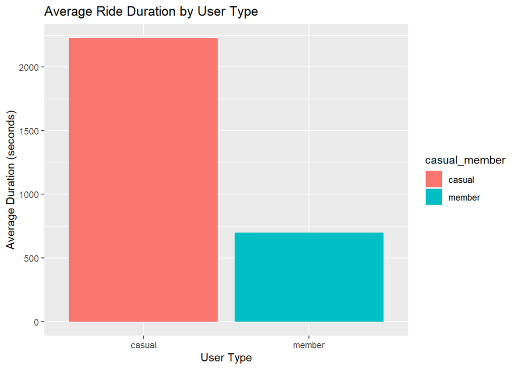

```r
# Plot Average Ride Duration
ggplot(avg_ride_duration, aes(x=casual_member,y=avg_duration,fill = casual_member))+
  geom_bar(stat = "identity")+
  labs(title = "Average Ride Duration by User Type", x = "User Type", y = "Average Duration (seconds)")
```

### Number of Rides by Day of the Week

```r
# Number of Rides by Day of the Week
rides_per_day <- all_data %>%
  group_by(casual_member, day_of_week) %>%
  summarise(num_rides = n()) %>%
  arrange(casual_member, day_of_week)
print(rides_per_day)
```

```
## # A tibble: 14 × 3
## # Groups:   casual_member [2]
##    casual_member day_of_week num_rides
##    <chr>               <int>     <int>
##  1 casual                  1     25327
##  2 casual                  2     12790
##  3 casual                  3     12041
##  4 casual                  4     10227
##  5 casual                  5     12206
##  6 casual                  6     12902
##  7 casual                  7     20694
##  8 member                  1     54084
##  9 member                  2    100423
## 10 member                  3    109778
## 11 member                  4     94612
## 12 member                  5     96966
## 13 member                  6     91060
## 14 member                  7     50930
```

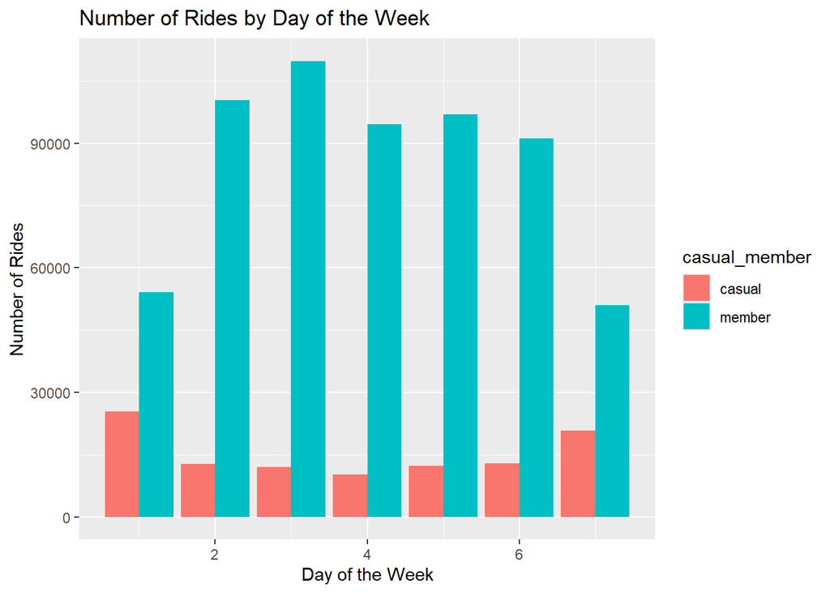

```r
# Plot Rides by Day of the Week
ggplot(rides_per_day, aes(x=day_of_week, y=num_rides, fill = casual_member))+
  geom_bar(stat = "identity", position = "dodge")+
  labs(title = "Number of Rides by Day of the Week", x= "Day of the Week", y= "Number of Rides")
```

### Popular Stations for Starting Rides

```r
# Popular Stations for Starting Rides
popular_stations <- all_data %>%
  group_by(casual_member, start_station_name) %>%
  summarise(num_rides = n()) %>%
  arrange(casual_member, desc(num_rides))
print(popular_stations)
```

```
## # A tibble: 1,204 × 3
## # Groups:   casual_member [2]
##    casual_member start_station_name           num_rides
##    <chr>         <chr>                            <int>
##  1 casual        Streeter Dr & Grand Ave           4991
##  2 casual        Lake Shore Dr & Monroe St         4853
##  3 casual        Shedd Aquarium                    2851
##  4 casual        Millennium Park                   2415
##  5 casual        Dusable Harbor                    1712
##  6 casual        Michigan Ave & Oak St             1605
##  7 casual        Adler Planetarium                 1414
##  8 casual        Michigan Ave & 8th St             1191
##  9 casual        Field Museum                      1163
## 10 casual        Michigan Ave & Washington St      1041
## # ℹ 1,194 more rows
```

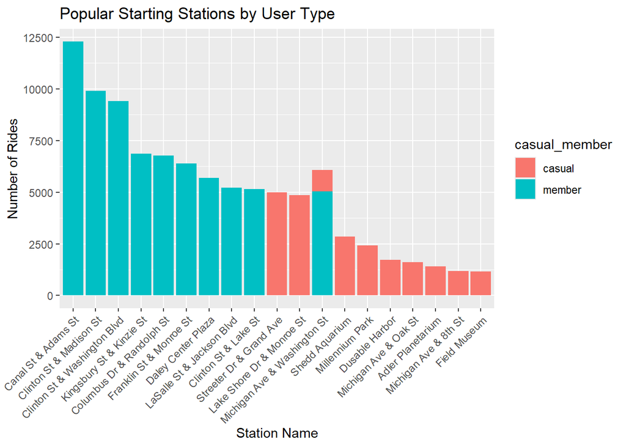

```r
# Plot Popular Starting Stations
top_stations <- popular_stations %>% group_by(casual_member) %>% top_n(10,num_rides)

ggplot(top_stations, aes(x=reorder(start_station_name, -num_rides), y=num_rides, fill = casual_member))+
  geom_bar(stat = "identity")+
  labs(title = "Popular Starting Stations by User Type", x = "Station Name", y = "Number of Rides")+
  theme(axis.text.x = element_text(angle = 45, hjust = 1))
```

### Ride Patterns

```r
# Frequency of Rides
ride_frequency <- all_data %>%
  group_by(casual_member) %>%
  summarise(total_rides = n(),
            avg_rides_per_day = mean(n()/length(unique(start_at))))

print(ride_frequency)
```

```
## # A tibble: 2 × 3
##   casual_member total_rides avg_rides_per_day
##   <chr>               <int>             <dbl>
## 1 casual             106187              2.47
## 2 member             597853              6.08
```

### Seasonal Trends

```r
# Month from Start Date
all_data$month <- month(all_data$start_at, label = TRUE)

# Rides by Month
rides_per_month <- all_data %>%
  group_by(casual_member, month) %>%
  summarise(num_rides = n())
```

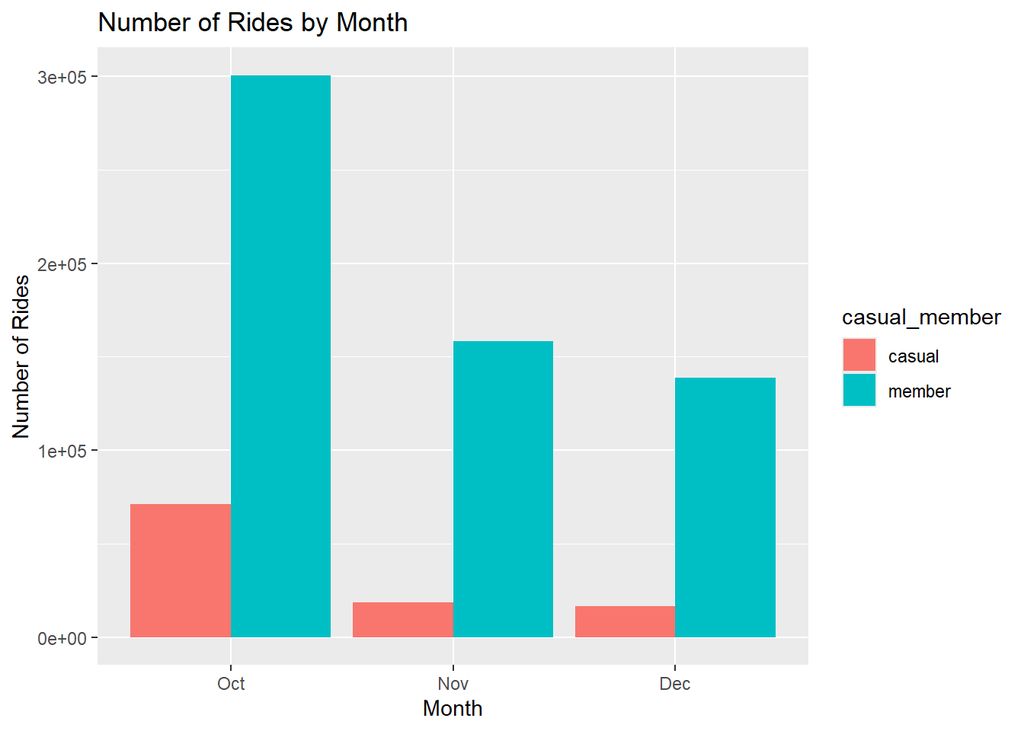

```r
ggplot(rides_per_month, aes(x=month, y=num_rides, fill = casual_member))+
  geom_bar(stat = "identity", position = "dodge")+
  labs(title = "Number of Rides by Month", x = "Month", y = "Number of Rides")
```

## Summary for Question 1

- Casual riders ride the bikes for, on average, longer bike trips.
- There are more annual members using the bike service on a daily basis.
- The top starting stations for members are: Canal St & Adams, Clinton St & Madison St, Clinton St & Washington Blvd, Kingsbury St & Kinzie St, and Columbus Dr & Randolph St.
- The top starting stations for casual riders are: Streeter Dr & Grand Ave, Lake Shore Dr & Monroe St, Shedd Aquarium, Millenium Park, and Dusable Harbor.
- More bikers, both casual and members, use the bike service in October the most, with November having slightly more riders than December, but with all 3 months, very low casual riders and high membership riders.

# Question 2: Why would casual riders buy Cyclistic annual memberships?

### Ride Duration

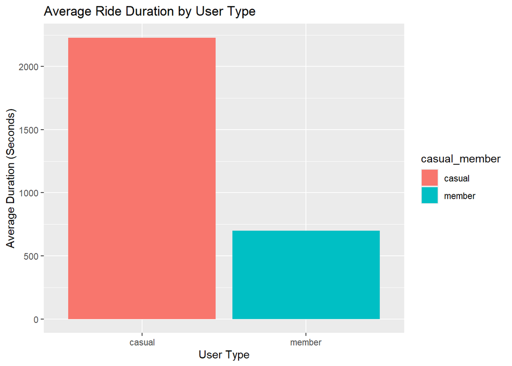

```r
# Average Ride Duration
ggplot(avg_ride_duration, aes(x=casual_member,y=avg_duration, fill = casual_member))+
  geom_bar(stat = "identity")+
  labs(title = "Average Ride Duration by User Type", x = "User Type", y = "Average Duration (Seconds)")
```

### Popular Routes and Stations

```r
# Popular Routes and Stations
popular_stations_casual <- all_data %>%
  filter(casual_member == "casual") %>%
  group_by(start_station_name) %>%
  summarise(num_rides = n()) %>%
  arrange(desc(num_rides)) %>%
  head(10)

print(popular_stations_casual)
```

```
## # A tibble: 10 × 2
##    start_station_name           num_rides
##    <chr>                            <int>
##  1 Streeter Dr & Grand Ave           4991
##  2 Lake Shore Dr & Monroe St         4853
##  3 Shedd Aquarium                    2851
##  4 Millennium Park                   2415
##  5 Dusable Harbor                    1712
##  6 Michigan Ave & Oak St             1605
##  7 Adler Planetarium                 1414
##  8 Michigan Ave & 8th St             1191
##  9 Field Museum                      1163
## 10 Michigan Ave & Washington St      1041
```

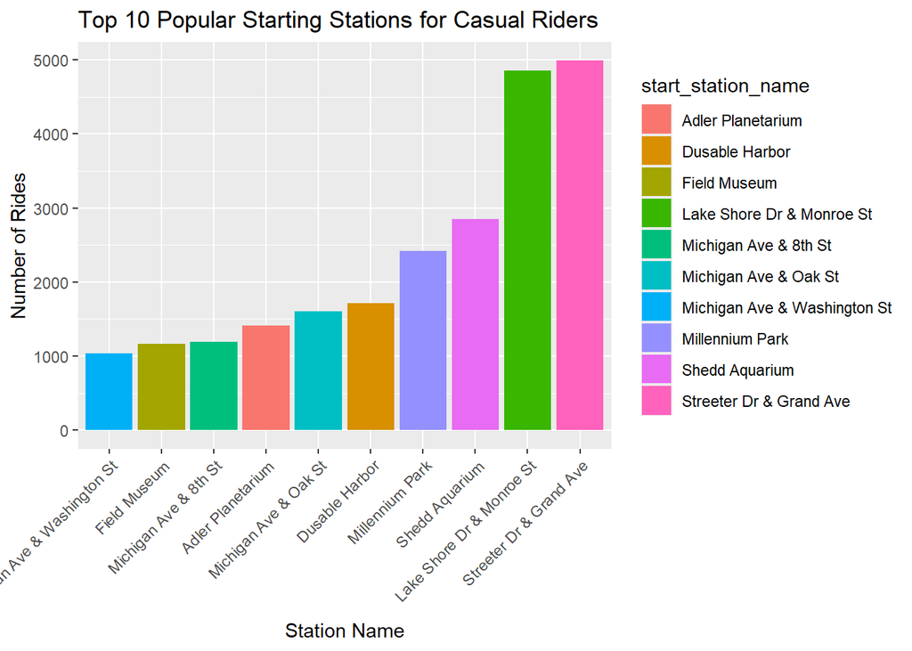

```r
# Plot Popular Stations for Casual Riders
ggplot(popular_stations_casual, aes(x=reorder(start_station_name, num_rides), y=num_rides, fill = start_station_name))+
  geom_bar(stat = "identity")+
  labs(title = "Top 10 Popular Starting Stations for Casual Riders", x= "Station Name", y = "Number of Rides")+
  theme(axis.text.x = element_text(angle = 45, hjust = 1))
```

### Peak Usage Time for Casual Riders

```r
# Extract hour from start time
all_data$hour <- hour(all_data$start_at)

# Peak Usage Times for Casual Riders
peak_time_casual <- all_data %>%
  filter(casual_member == "casual") %>%
  group_by(hour) %>%
  summarise(num_rides = n()) %>%
  arrange(desc(num_rides))

print(peak_time_casual)
```

```
## # A tibble: 24 × 2
##     hour num_rides
##    <int>     <int>
##  1    15     10879
##  2    14     10215
##  3    16     10120
##  4    13      9842
##  5    12      9532
##  6    17      9240
##  7    11      8115
##  8    10      6023
##  9    18      5845
## 10     9      4308
## # ℹ 14 more rows
```

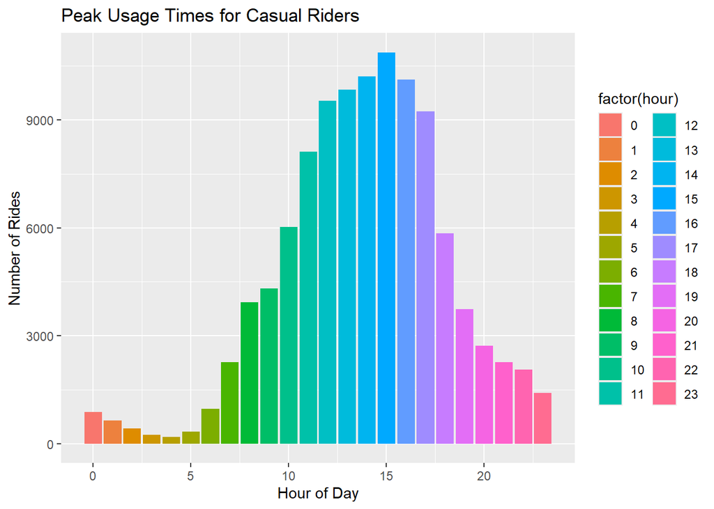

```r
# Plot Peak Usage Times for Casual Riders
ggplot(peak_time_casual, aes(x=hour, y=num_rides, fill = factor(hour)))+
  geom_bar(stat = "identity")+
  labs(title = "Peak Usage Times for Casual Riders", x = "Hour of Day", y = "Number of Rides")
```

## Summary for Question 2

- Casual riders ride, on average, longer than current members, sometimes even a half hour longer per trip.
- Popular starting stations for casual riders include Streeter Dr & Grand Ave, Lake Shore Dr & Monroe St, Shedd Aquarium, Millenium Park, and Dusable Harbor.
- Peak usage times for casual riders tend to be around specific hours of the day, indicating when they might benefit most from an annual membership.

# Question 3: How can Cyclistic use digital media to influence casual riders to become members?

### Target Groups for Campaign

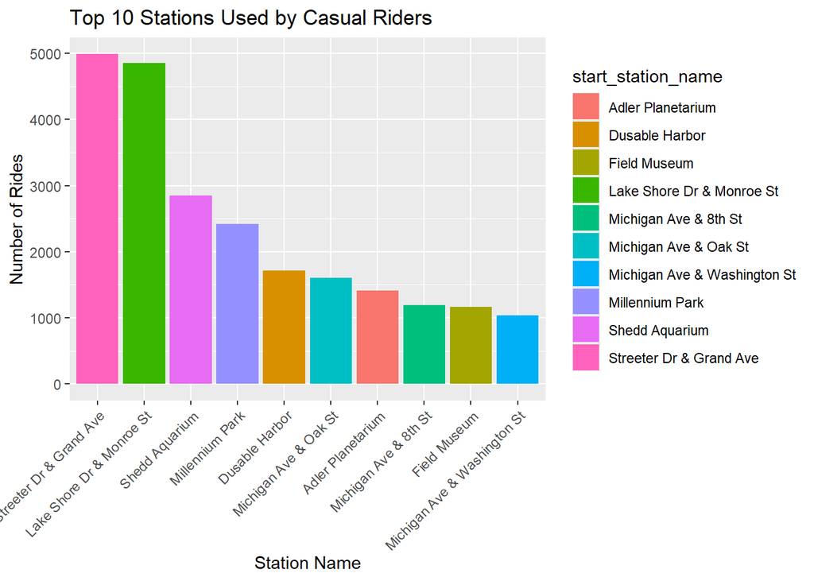

```r
# Top Stations Used by Casual Riders
top_stations_casual <- popular_stations %>%
  filter(casual_member == "casual") %>%
  top_n(10, num_rides)

# Plot Top 10 Stations Used by Casual Riders
ggplot(top_stations_casual, aes(x=reorder(start_station_name, -num_rides), y= num_rides, fill = start_station_name))+
  geom_bar(stat = "identity")+
  labs(title = "Top 10 Stations Used by Casual Riders", x = "Station Name", y = "Number of Rides")+
  theme(axis.text.x = element_text(angle = 45, hjust = 1))
```

### Email Template

Subject: Upgrade to Cyclistic Annual Membership and Save!

Dear [User Name],

We noticed you love riding with Cyclistic! Why not take advantage of our annual membership and enjoy unlimited rides all year round?

Sign up now and save [amount] compared to your current usage. Plus, enjoy exclusive member benefits like [benefit 1], [benefit 2], and more!

Don’t miss out – upgrade today and keep riding with ease.

Best, The Cyclistic Team

### Banner Content

Upgrade to Cyclistic Annual Membership and Ride More for Less! Enjoy unlimited rides and exclusive benefits. Sign up now!

# Summary for Question 3

- Target the most frequently used stations by casual riders, especially during busy biking times.
- Engage on social media by showcasing the benefits of memberships, including possible savings, convenience, and exclusive perks.
- Send personalized emails to frequent casual riders, offering discounts for memberships.

# Conclusion

By leveraging insights from the data, Cyclistic can effectively encourage casual riders to become annual members. The analysis shows that casual riders tend to take longer trips and have specific peak usage times and popular starting stations. Digital media campaigns targeting these key insights can highlight the benefits of membership, such as cost savings and convenience. Personalized emails and social media engagement, along with strategic promotions at popular stations, can drive conversions from casual riders to annual members, enhancing their overall experience with Cyclistic.